# ENVS363 Computational Essay

*Imported libraries*

```python
%matplotlib inline

import numpy as np
import pandas as pd
from pysal.lib import weights
from pysal.lib import examples
from pysal.viz import mapclassify
from splot.esda import (moran_scatterplot, lisa_cluster, plot_local_autocorrelation)
import geopandas as gpd
import contextily as ctx
import seaborn as sns
import matplotlib.pyplot as plt
from sklearn.cluster import DBSCAN
from ipywidgets import interact, fixed
from sklearn import cluster
from shapely.geometry import Point
from keplergl import KeplerGl
```

*Compulsory datasets*

```python
neis = gpd.read_file("https://darribas.org/gds_course/_downloads/a2bdb4c2a088e602c3bd6490ab1d26fa/toronto_socio-economic.gpkg")
photos = pd.read_csv("https://darribas.org/gds_course/_downloads/fc771c3b1b9e0ee00e875bb2d293adcd/toronto_flickr_subset.csv")
```

*Additional datasets?*

```python
imd_data = gpd.read_file("M:/Year 3/Semester 1/ENVS363/neighbourhood-profiles-2016-csv.csv")
```

## Part I

The first task is to select two variables from the socioeconomic characteristics of Toronto dataset. From the list of variables, I have selected 'hh_median_income2015' and 'deg_bachelor'.

*List of socioeconomic characteristics*

```python
pd.read_csv("https://darribas.org/gds_course/_downloads/8944151f1b7df7b1f38b79b7a73eb2d0/toronto_socio-economic_vars.csv")
```

|  | _id | name | Category | Topic | Data Source | Characteristic |
| --- | --- | --- | --- | --- | --- | --- |
| 0 | 3 | population2016 | Population | Population and dwellings | Census Profile 98-316-X2016001 | Population, 2016 |
| 1 | 8 | population_sqkm | Population | Population and dwellings | Census Profile 98-316-X2016001 | Population density per square kilometre |
| 2 | 10 | pop_0-14_yearsold | Population | Age characteristics | Census Profile 98-316-X2016001 | Children (0-14 years) |
| 3 | 11 | pop_15-24_yearsold | Population | Age characteristics | Census Profile 98-316-X2016001 | Youth (15-24 years) |
| 4 | 12 | pop_25-54_yearsold | Population | Age characteristics | Census Profile 98-316-X2016001 | Working Age (25-54 years) |
| 5 | 13 | pop_55-64_yearsold | Population | Age characteristics | Census Profile 98-316-X2016001 | Pre-retirement (55-64 years) |
| 6 | 14 | pop_65+_yearsold | Population | Age characteristics | Census Profile 98-316-X2016001 | Seniors (65+ years) |
| 7 | 15 | pop_85+_yearsold | Population | Age characteristics | Census Profile 98-316-X2016001 | Older Seniors (85+ years) |
| 8 | 1018 | hh_median_income2015 | Income | Income of households in 2015 | Census Profile 98-316-X2016001 | Total - Income statistics in 2015 for private ... |
| 9 | 1149 | canadian_citizens | Immigration and citizenship | Citizenship | Census Profile 98-316-X2016001 | Canadian citizens aged 18 and over |
| 10 | 1711 | deg_bachelor | Education | Highest certificate, diploma or degree | Census Profile 98-316-X2016001 | Bachelor's degree |
| 11 | 1713 | deg_medics | Education | Highest certificate, diploma or degree | Census Profile 98-316-X2016001 | Degree in medicine, dentistry, veterinar... |
| 12 | 1714 | deg_phd | Education | Highest certificate, diploma or degree | Census Profile 98-316-X2016001 | Earned doctorate |
| 13 | 1887 | employed | Labour | Labour force status | Census Profile 98-316-X2016001 | Employed |
| 14 | 1636 | bedrooms_0 | Housing | Household characteristics | Census Profile 98-316-X2016001 | No bedrooms |
| 15 | 1637 | bedrooms_1 | Housing | Household characteristics | Census Profile 98-316-X2016001 | 1 bedroom |
| 16 | 1638 | bedrooms_2 | Housing | Household characteristics | Census Profile 98-316-X2016001 | 2 bedrooms |
| 17 | 1639 | bedrooms_3 | Housing | Household characteristics | Census Profile 98-316-X2016001 | 3 bedrooms |
| 18 | 1641 | bedrooms_4+ | Housing | Household characteristics | Census Profile 98-316-X2016001 | 4 or more bedrooms |

*Choropleth maps for Median Income and Bachelor Degree*

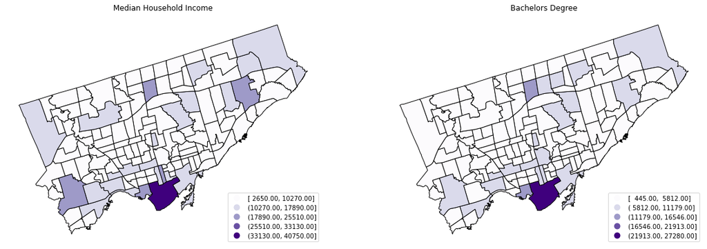

```python
# Setup figure and axis
f, ax = plt.subplots(1, 2, figsize= (20,15))

# Plot the first map. Using ax[0] to change the title and axis label
neis.plot(column='hh_median_income2015', scheme='equal_interval',k=5, ax=ax[0], cmap='Purples',
    edgecolor='k', legend=True,
          legend_kwds={'loc': 'lower right'})

ax[0].set_title('Median Household Income')
ax[0].set_ylabel('ylabel_for_the_first_map')

# Plot the second map. Using ax[1] to change the title and axis label
neis.plot(column='deg_bachelor', scheme='equal_interval', k=5, ax=ax[1], cmap='Purples',
    edgecolor='k', legend=True,
         legend_kwds={'loc': 'lower right'})
ax[1].set_title('Bachelors Degree')
ax[1].set_ylabel('ylabel_for_the_second_map')

# Remove axis
ax[0].set_axis_off()
ax[1].set_axis_off()

# Save figures
plt.savefig('Median Income and Bachelor Degree Choropleth.jpg')
```

Both choropleths display one significant cluster featuring the highest concentration of median household income and bachelors degree. Furthermore, both choropleths display similar patterns of clustering suggesting there is a relationship between higher education attainment and median income. However, Choropleths only geovisually represent this relationship therefore, in task three Local Spatial Autocorrelation will be used to test the relationships between each observation and its surroundings. Local Indicators of Spatial Association (LISAs) are a local counter-part of Moran's I utilised in Local Spatial Autocorrelation which identifies 'hotspots' by focusing on the relationship between each observation and its surroundings [(Anselin, 1995)](https://doi.org/10.1111/j.1538-4632.1995.tb00338.x).

*Spatial weights matrix formally encodes geographical space into a numerical form needed for spatial autocorrelation*

```python
# Create the spatial weights matrix
%time w = weights.Queen.from_dataframe(neis, idVariable="_id")
```

```
Wall time: 183 ms
```

*Matrix is row-standardized so every row of the matrix sums up to one*

```python
# Row standardize the matrix
w.transform = 'R'
```

*Average value is then subtracted and divided by the standard deviation of each observation*

```python
neis['deg_bachelor_std'] = (
    neis['deg_bachelor'] - neis['deg_bachelor'].mean()
) / neis['deg_bachelor'].std()
```

```python
neis['hh_median_income2015_std'] = (
    neis['hh_median_income2015'] - neis['hh_median_income2015'].mean()
) / neis['hh_median_income2015'].std()
```

*The spatial lag averages the neighbouring values of a location*

```python
neis['w_deg_bachelor_std'] = weights.lag_spatial(w, neis['deg_bachelor_std'])
neis['w_hh_median_income2015_std'] = weights.lag_spatial(w, neis['hh_median_income2015_std'])
```

*Degree of Spatial Autocorrelation*

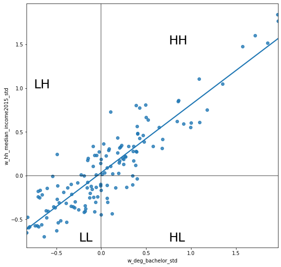

```python
# Setup the figure and axis
f, ax = plt.subplots(1, figsize=(9, 9))

# Plot values
sns.regplot(x='w_deg_bachelor_std', y='w_hh_median_income2015_std', data=neis, ci=None)

# Add vertical and horizontal lines
plt.axvline(0, c='k', alpha=0.5)
plt.axhline(0, c='k', alpha=0.5)
plt.text(.75, 1.5, "HH", fontsize=25)
plt.text(.75, -.75, "HL", fontsize=25)
plt.text(-.75, 1, "LH", fontsize=25)
plt.text(-.25, -.75, "LL", fontsize=25)

# Save figures
plt.savefig('Median Income and Bachelor Degree Local Spatial Autocorrelion.jpg')
```

LISAs classify observations into quadrants which fall into the Moran Plot. LISAs identify cases in which the comparison between the value of an observation and the average of its neighbours is either more similar (HH, LL) or dissimilar (HL, LH) than we would expect from pure chance. The output suggests that there is a positive local spatial autocorrelation between higher education attainment and median income suggesting similar values (HH, LL) of tend to be clustered together. This supports the relationship between higher education attainment and median income.